# study2 data raw

Joseph Outa

2025-5-11

```r
knit_by_pkgdown <- !is.null(knitr::opts_chunk$get("fig.retina"))
knitr::opts_chunk$set(
  warning = TRUE, # show warnings during codebook generation
  message = TRUE, # show messages during codebook generation
  error = TRUE, # do not interrupt codebook generation in case of errors,
                # TRUE is usually better for debugging
  echo = TRUE  # show R code
)

library(pacman)
pacman::p_load(tidyverse, here, codebook)
ggplot2::theme_set(ggplot2::theme_bw())
```

# 1 Read data

```
## # A tibble: 100 × 2
##    subject_id     n
##    <fct>      <int>
##  1 subj_1        21
##  2 subj_10       21
##  3 subj_100      21
##  4 subj_11       21
##  5 subj_12       21
##  6 subj_13       21
##  7 subj_14       21
##  8 subj_15       21
##  9 subj_16       21
## 10 subj_17       21
## # ℹ 90 more rows
```

```r
codebook::codebook(d)
```

### 1.0.1 Metadata

#### 1.0.1.1 Description

**Dataset name**: Raw data for Study 2

**Metadata for search engines**

- **Date published**: 2025-05-11

| x |
| --- |
| subject_id |
| trial_type |
| trial_index |
| plugin_version |
| time_elapsed |
| trial_id |
| rt |
| stimulus |
| response |
| view_history |
| condition |
| itemB |
| causal_itemA |
| similarity_itemA |
| selected_choice |
| correct_response_attn |
| feedback |
| age |
| ethnicity |
| gender |
| race |

## 1.1 Variables

### 1.1.1 subject_id

Subject ids for all 100 subjects

#### 1.1.1.1 Distribution

```
## 100  unique, categorical values, so not shown.
```

0 missing values.

#### 1.1.1.2 Summary statistics

| name | label | data_type | ordered | value_labels | n_missing | complete_rate | n_unique | top_counts |
| --- | --- | --- | --- | --- | --- | --- | --- | --- |
| subject_id | Subject ids for all 100 subjects | factor | FALSE | 1. subj_1, 2. subj_10, 3. subj_100, 4. subj_11, 5. subj_12, 6. subj_13, 7. subj_14, 8. subj_15, 9. subj_16, 10. subj_17, 11. subj_18, 12. subj_19, 13. subj_2, 14. subj_20, 15. subj_21, 16. subj_22, 17… | 0 | 1 | 100 | sub: 21, sub: 21, sub: 21, sub: 21 |

### 1.1.2 trial_type

Type of jspsych trial. Trials in jspsych represent checkpoints in the experiment, such as the instructions page, the survey page etc

#### 1.1.2.1 Distribution

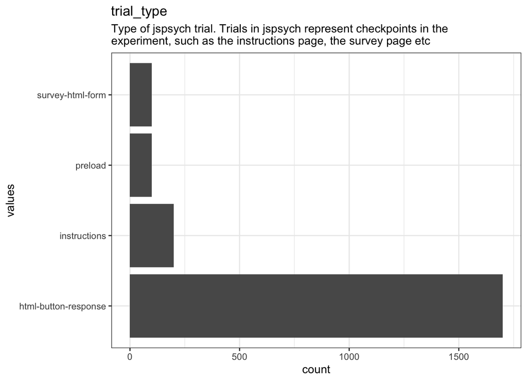

Figure 1.1: Distribution of values for trial_type

0 missing values.

#### 1.1.2.2 Summary statistics

| name | label | data_type | n_missing | complete_rate | n_unique | empty | min | max | whitespace |
| --- | --- | --- | --- | --- | --- | --- | --- | --- | --- |
| trial_type | Type of jspsych trial. Trials in jspsych represent checkpoints in the experiment, such as the instructions page, the survey page etc | character | 0 | 1 | 4 | 0 | 7 | 20 | 0 |

### 1.1.3 trial_index

Each subject had about 20 jspsych trials. This does not refer to experimental trials, but overall trials including instructions

#### 1.1.3.1 Distribution

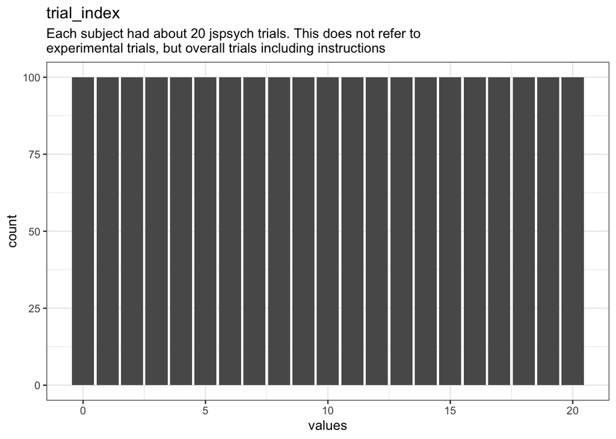

Figure 1.2: Distribution of values for trial_index

0 missing values.

#### 1.1.3.2 Summary statistics

| name | label | data_type | n_missing | complete_rate | min | median | max | mean | sd | hist |
| --- | --- | --- | --- | --- | --- | --- | --- | --- | --- | --- |
| trial_index | Each subject had about 20 jspsych trials. This does not refer to experimental trials, but overall trials including instructions | numeric | 0 | 1 | 0 | 10 | 20 | 10 | 6.056743 | ▇▆▆▆▆ |

### 1.1.4 plugin_version

Plugin version that the subject had for the jspsych trials

#### 1.1.4.1 Distribution

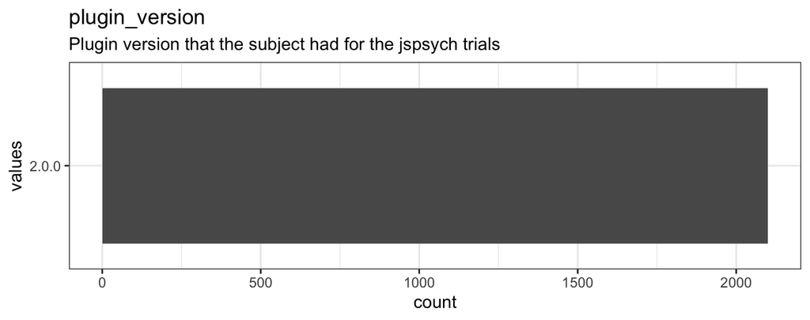

Figure 1.3: Distribution of values for plugin_version

0 missing values.

#### 1.1.4.2 Summary statistics

| name | label | data_type | n_missing | complete_rate | n_unique | empty | min | max | whitespace |
| --- | --- | --- | --- | --- | --- | --- | --- | --- | --- |
| plugin_version | Plugin version that the subject had for the jspsych trials | character | 0 | 1 | 1 | 0 | 5 | 5 | 0 |

### 1.1.5 time_elapsed

Time in milliseconds the subject spent on a given trial

#### 1.1.5.1 Distribution

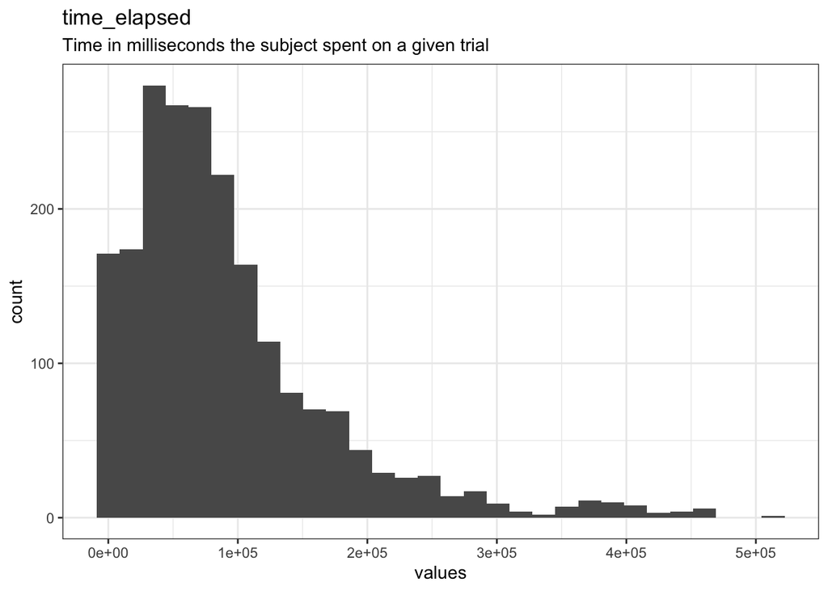

Figure 1.4: Distribution of values for time_elapsed

0 missing values.

#### 1.1.5.2 Summary statistics

| name | label | data_type | n_missing | complete_rate | min | median | max | mean | sd | hist |
| --- | --- | --- | --- | --- | --- | --- | --- | --- | --- | --- |
| time_elapsed | Time in milliseconds the subject spent on a given trial | numeric | 0 | 1 | 3 | 72841 | 513328 | 91938.55 | 80534.34 | ▇▃▁▁▁ |

### 1.1.6 trial_id

Researcher-assigned trial names. Trials highlighted were the consent and demorgraphics_survey

#### 1.1.6.1 Distribution

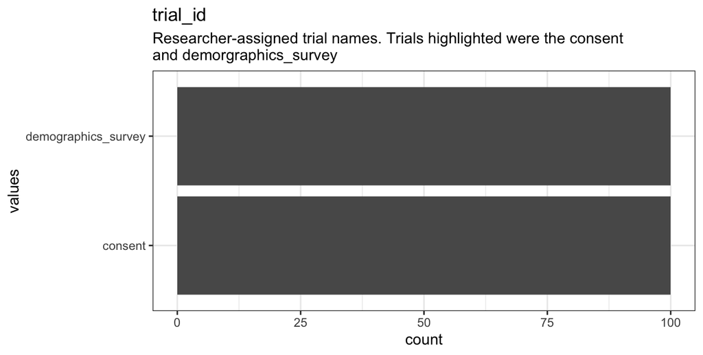

Figure 1.5: Distribution of values for trial_id

1900 missing values.

#### 1.1.6.2 Summary statistics

| name | label | data_type | n_missing | complete_rate | n_unique | empty | min | max | whitespace |
| --- | --- | --- | --- | --- | --- | --- | --- | --- | --- |
| trial_id | Researcher-assigned trial names. Trials highlighted were the consent and demorgraphics_survey | character | 1900 | 0.0952381 | 2 | 0 | 7 | 19 | 0 |

### 1.1.7 rt

Time it takes in milliseconds from when the page loads to when subject clicks on continue button

#### 1.1.7.1 Distribution

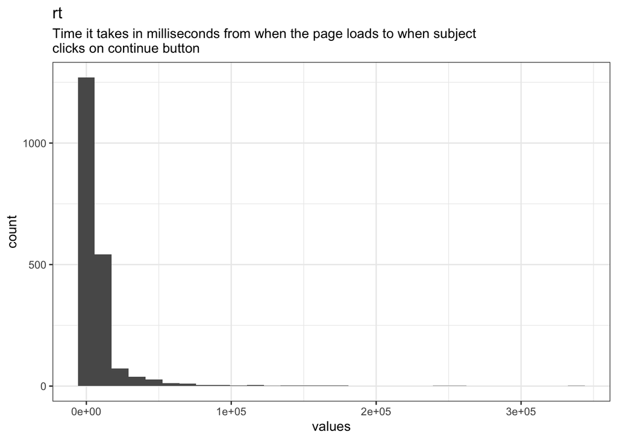

Figure 1.6: Distribution of values for rt

100 missing values.

#### 1.1.7.2 Summary statistics

| name | label | data_type | n_missing | complete_rate | min | median | max | mean | sd | hist |
| --- | --- | --- | --- | --- | --- | --- | --- | --- | --- | --- |
| rt | Time it takes in milliseconds from when the page loads to when subject clicks on continue button | numeric | 100 | 0.952381 | 188 | 4545 | 338420 | 9532.981 | 19224.22 | ▇▁▁▁▁ |

### 1.1.8 stimulus

Html-formatted string describing the stimulus presented to participant on trials that had a stimulus

#### 1.1.8.1 Distribution

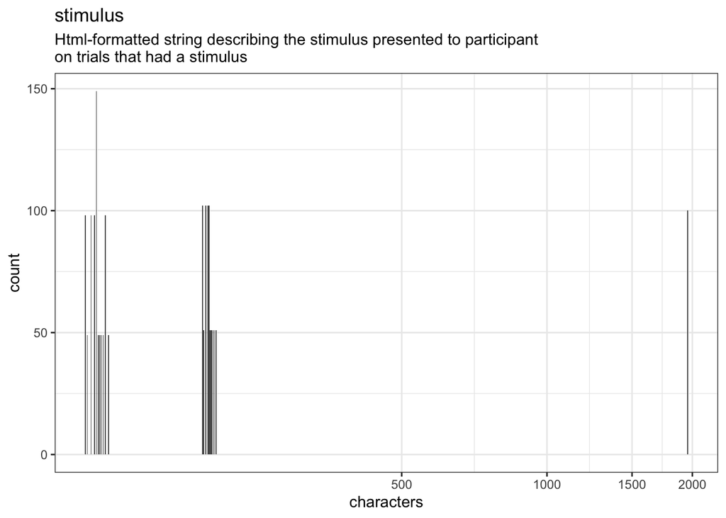

Figure 1.7: Distribution of values for stimulus

400 missing values.

#### 1.1.8.2 Summary statistics

| name | label | data_type | n_missing | complete_rate | n_unique | empty | min | max | whitespace |
| --- | --- | --- | --- | --- | --- | --- | --- | --- | --- |
| stimulus | Html-formatted string describing the stimulus presented to participant on trials that had a stimulus | character | 400 | 0.8095238 | 33 | 0 | 110 | 1954 | 0 |

### 1.1.9 response

responses on the respective trials, which included 0 or 1 for the main trial questions, and dictionaries of demographic values for the demographic survey items

#### 1.1.9.1 Distribution

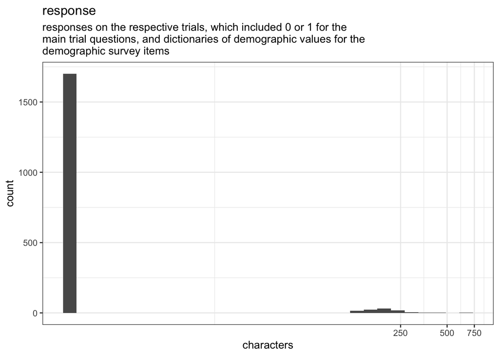

Figure 1.8: Distribution of values for response

300 missing values.

#### 1.1.9.2 Summary statistics

| name | label | data_type | n_missing | complete_rate | n_unique | empty | min | max | whitespace |
| --- | --- | --- | --- | --- | --- | --- | --- | --- | --- |
| response | responses on the respective trials, which included 0 or 1 for the main trial questions, and dictionaries of demographic values for the demographic survey items | character | 300 | 0.8571429 | 102 | 0 | 1 | 723 | 0 |

### 1.1.10 view_history

A dictionary containing the index of the page and viewing time in milliseconds

#### 1.1.10.1 Distribution

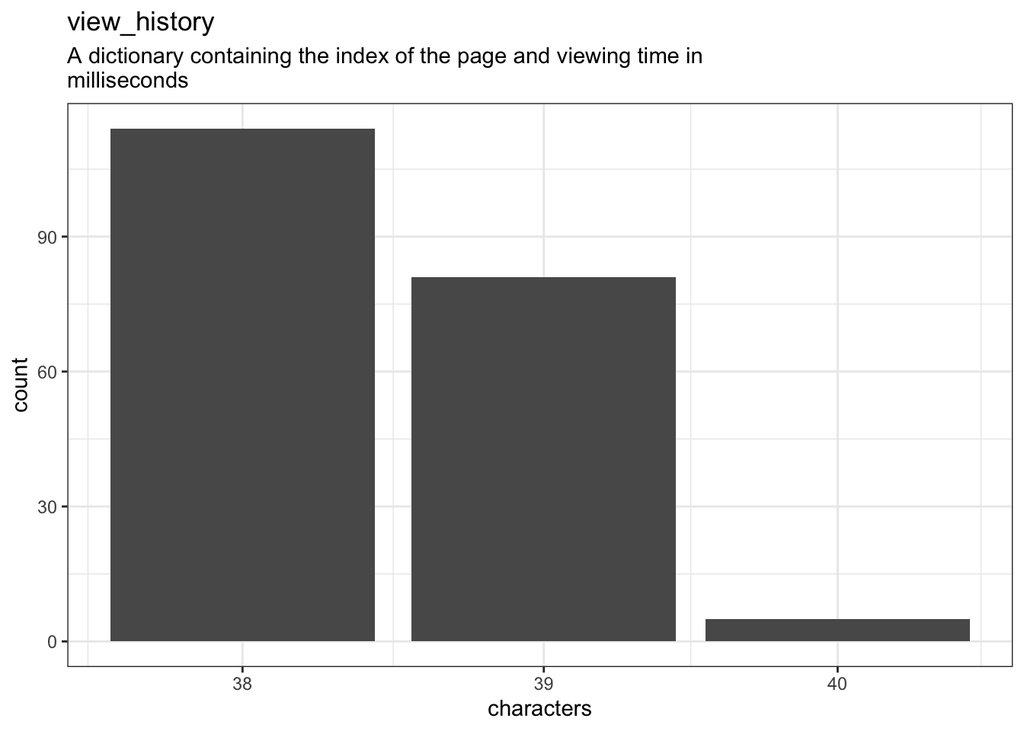

Figure 1.9: Distribution of values for view_history

1900 missing values.

#### 1.1.10.2 Summary statistics

| name | label | data_type | n_missing | complete_rate | n_unique | empty | min | max | whitespace |
| --- | --- | --- | --- | --- | --- | --- | --- | --- | --- |
| view_history | A dictionary containing the index of the page and viewing time in milliseconds | character | 1900 | 0.0952381 | 200 | 0 | 38 | 40 | 0 |

### 1.1.11 condition

a character type describing the condition assignment. it includes the two experimental conditions, Similarity (which means Inference Condition) and Intervention, as well as the attention check trial labels

#### 1.1.11.1 Distribution

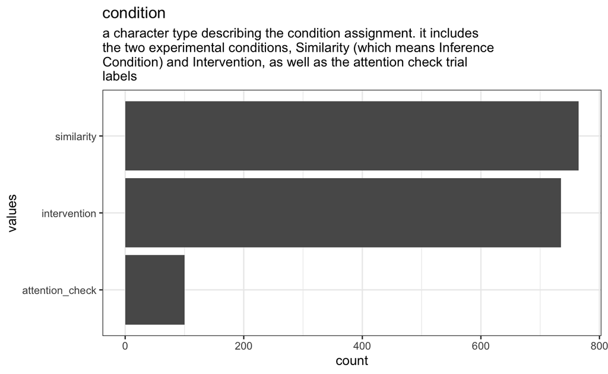

Figure 1.10: Distribution of values for condition

500 missing values.

#### 1.1.11.2 Summary statistics

| name | label | data_type | n_missing | complete_rate | n_unique | empty | min | max | whitespace |
| --- | --- | --- | --- | --- | --- | --- | --- | --- | --- |
| condition | a character type describing the condition assignment. it includes the two experimental conditions, Similarity (which means Inference Condition) and Intervention, as well as the attention check trial l… | character | 500 | 0.7619048 | 3 | 0 | 10 | 15 | 0 |

### 1.1.12 itemB

The target item in both the Intervention and Inference Tasks (and also the attention check question)

#### 1.1.12.1 Distribution

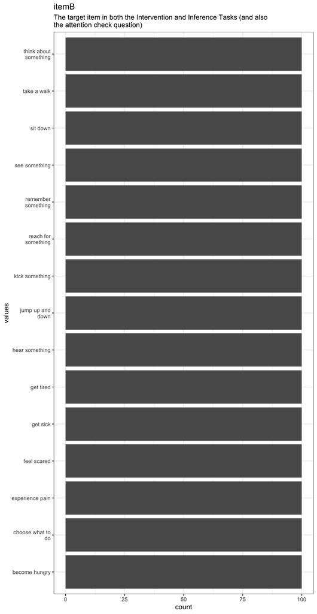

Figure 1.11: Distribution of values for itemB

600 missing values.

#### 1.1.12.2 Summary statistics

| name | label | data_type | n_missing | complete_rate | n_unique | empty | min | max | whitespace |
| --- | --- | --- | --- | --- | --- | --- | --- | --- | --- |
| itemB | The target item in both the Intervention and Inference Tasks (and also the attention check question) | character | 600 | 0.7142857 | 15 | 0 | 8 | 21 | 0 |

### 1.1.13 causal_itemA

The causal item choice in the Intervention and Inference Tasks, and in the attention check question

#### 1.1.13.1 Distribution

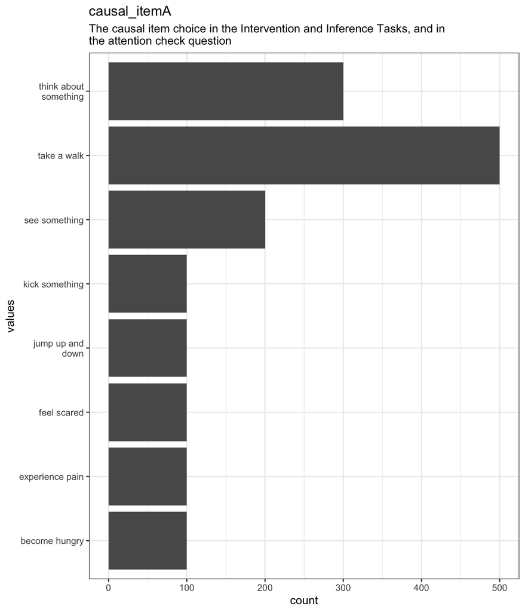

Figure 1.12: Distribution of values for causal_itemA

600 missing values.

#### 1.1.13.2 Summary statistics

| name | label | data_type | n_missing | complete_rate | n_unique | empty | min | max | whitespace |
| --- | --- | --- | --- | --- | --- | --- | --- | --- | --- |
| causal_itemA | The causal item choice in the Intervention and Inference Tasks, and in the attention check question | character | 600 | 0.7142857 | 8 | 0 | 11 | 21 | 0 |

### 1.1.14 similarity_itemA

The similar item choice in the Intervention and Inference Tasks, and in the attention check question

#### 1.1.14.1 Distribution

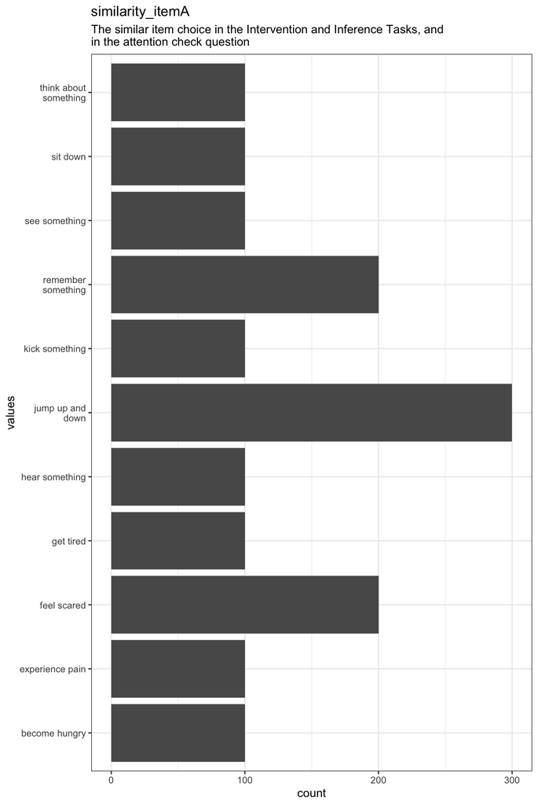

Figure 1.13: Distribution of values for similarity_itemA

600 missing values.

#### 1.1.14.2 Summary statistics

| name | label | data_type | n_missing | complete_rate | n_unique | empty | min | max | whitespace |
| --- | --- | --- | --- | --- | --- | --- | --- | --- | --- |
| similarity_itemA | The similar item choice in the Intervention and Inference Tasks, and in the attention check question | character | 600 | 0.7142857 | 11 | 0 | 8 | 21 | 0 |

### 1.1.15 selected_choice

A html formatted string showing the choice subjects selected in the experimental trial and attention check

#### 1.1.15.1 Distribution

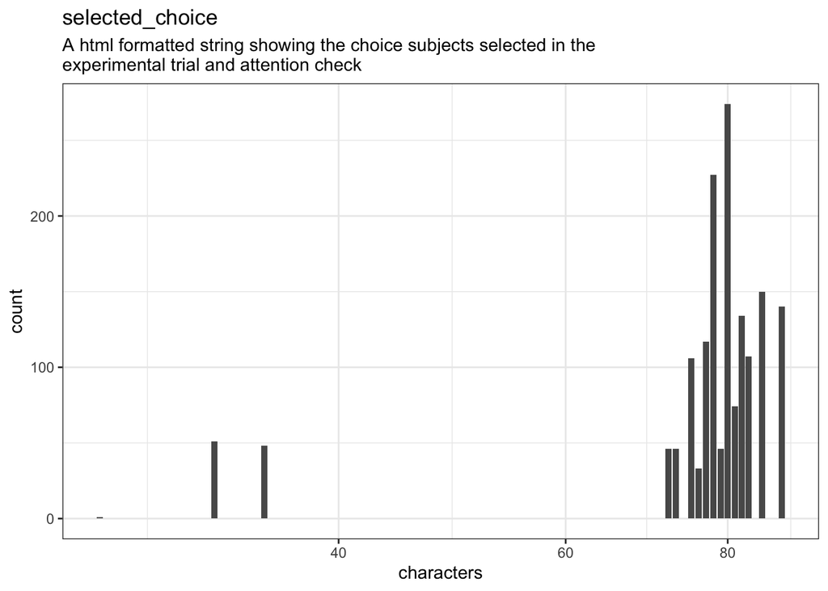

Figure 1.14: Distribution of values for selected_choice

500 missing values.

#### 1.1.15.2 Summary statistics

| name | label | data_type | n_missing | complete_rate | n_unique | empty | min | max | whitespace |
| --- | --- | --- | --- | --- | --- | --- | --- | --- | --- |
| selected_choice | A html formatted string showing the choice subjects selected in the experimental trial and attention check | character | 500 | 0.7619048 | 27 | 0 | 26 | 88 | 0 |

### 1.1.16 correct_response_attn

The correct response for the attention check question

#### 1.1.16.1 Distribution

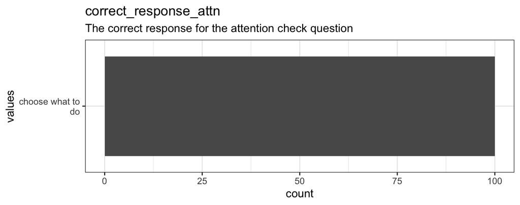

Figure 1.15: Distribution of values for correct_response_attn

2000 missing values.

#### 1.1.16.2 Summary statistics

| name | label | data_type | n_missing | complete_rate | n_unique | empty | min | max | whitespace |
| --- | --- | --- | --- | --- | --- | --- | --- | --- | --- |
| correct_response_attn | The correct response for the attention check question | character | 2000 | 0.047619 | 1 | 0 | 17 | 17 | 0 |

### 1.1.17 feedback

Feedback provided by subjects

#### 1.1.17.1 Distribution

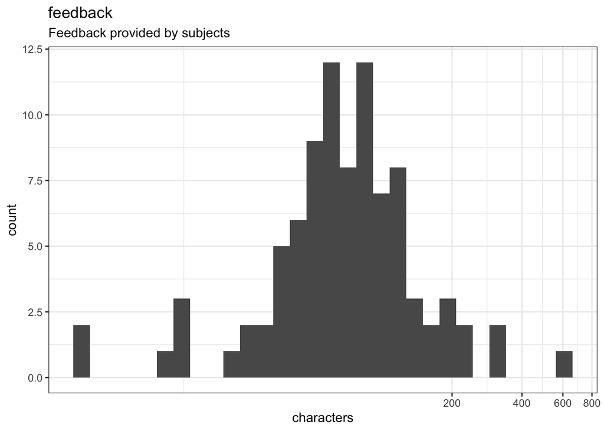

Figure 1.16: Distribution of values for feedback

2009 missing values.

#### 1.1.17.2 Summary statistics

| name | label | data_type | n_missing | complete_rate | n_unique | empty | min | max | whitespace |
| --- | --- | --- | --- | --- | --- | --- | --- | --- | --- |
| feedback | Feedback provided by subjects | character | 2009 | 0.0433333 | 91 | 0 | 4 | 587 | 0 |

### 1.1.18 age

#### 1.1.18.1 Distribution

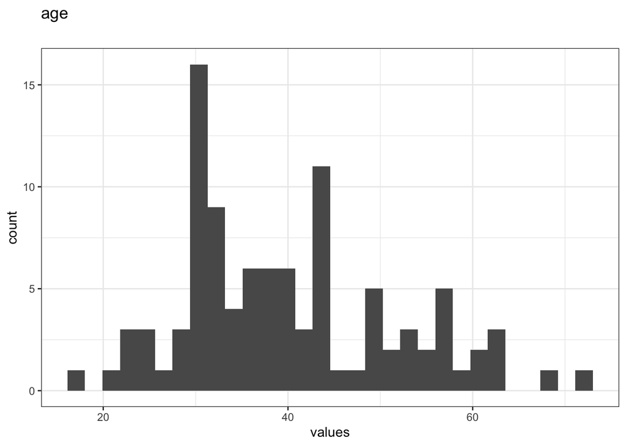

Figure 1.17: Distribution of values for age

2000 missing values.

#### 1.1.18.2 Summary statistics

| name | data_type | n_missing | complete_rate | min | median | max | mean | sd | hist | label |
| --- | --- | --- | --- | --- | --- | --- | --- | --- | --- | --- |
| age | numeric | 2000 | 0.047619 | 18 | 38 | 73 | 39.95 | 11.56394 | ▂▇▃▃▁ | NA |

### 1.1.19 ethnicity

#### 1.1.19.1 Distribution

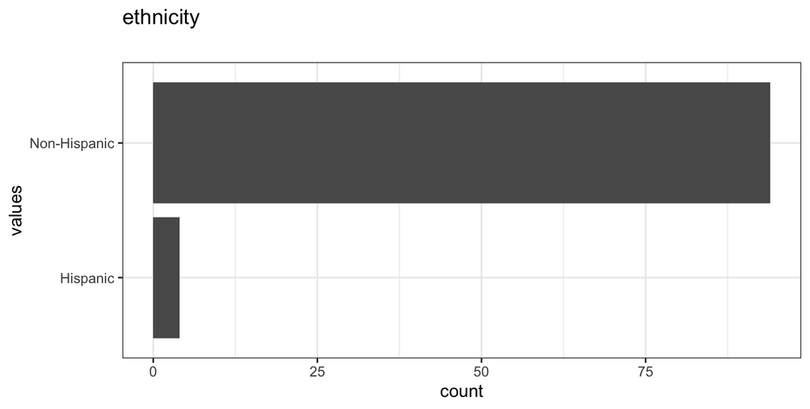

Figure 1.18: Distribution of values for ethnicity

2002 missing values.

#### 1.1.19.2 Summary statistics

| name | data_type | n_missing | complete_rate | n_unique | empty | min | max | whitespace | label |
| --- | --- | --- | --- | --- | --- | --- | --- | --- | --- |
| ethnicity | character | 2002 | 0.0466667 | 2 | 0 | 8 | 12 | 0 | NA |

### 1.1.20 gender

#### 1.1.20.1 Distribution

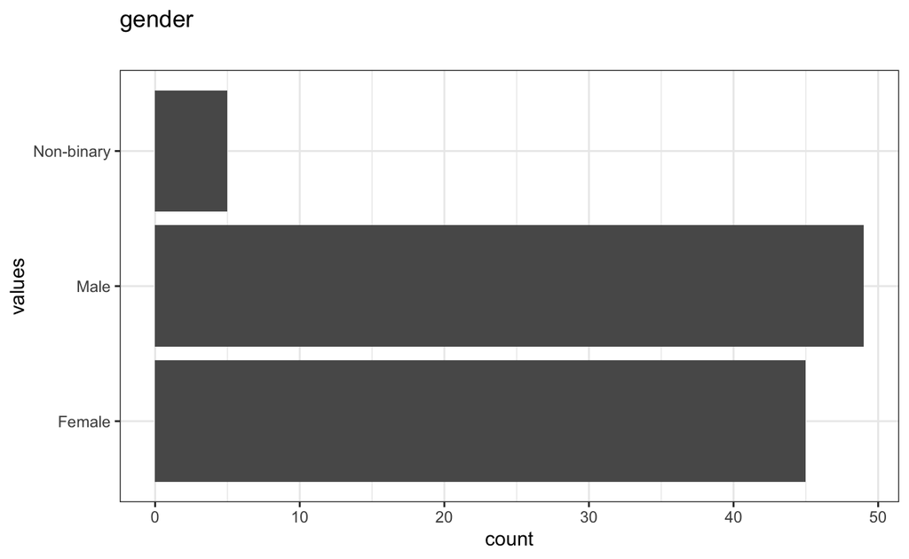

Figure 1.19: Distribution of values for gender

2001 missing values.

#### 1.1.20.2 Summary statistics

| name | data_type | n_missing | complete_rate | n_unique | empty | min | max | whitespace | label |
| --- | --- | --- | --- | --- | --- | --- | --- | --- | --- |
| gender | character | 2001 | 0.0471429 | 3 | 0 | 4 | 10 | 0 | NA |

### 1.1.21 race

#### 1.1.21.1 Distribution

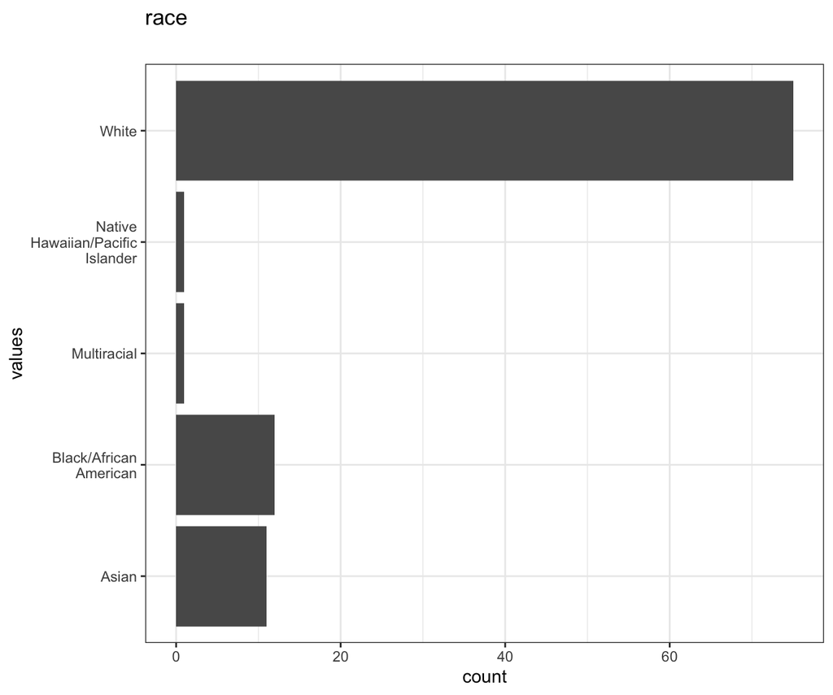

Figure 1.20: Distribution of values for race

2000 missing values.

#### 1.1.21.2 Summary statistics

| name | data_type | n_missing | complete_rate | n_unique | empty | min | max | whitespace | label |
| --- | --- | --- | --- | --- | --- | --- | --- | --- | --- |
| race | character | 2000 | 0.047619 | 5 | 0 | 5 | 32 | 0 | NA |

## 1.2 Missingness report

| description | rt | response | stimulus | condition | selected_choice | itemB | causal_itemA | similarity_itemA | trial_id | view_history | correct_response_attn | age | race | gender | ethnicity | feedback | var_miss | n_miss |
| --- | --- | --- | --- | --- | --- | --- | --- | --- | --- | --- | --- | --- | --- | --- | --- | --- | --- | --- |
| Missing values per variable | 100 | 300 | 400 | 500 | 500 | 600 | 600 | 600 | 1900 | 1900 | 2000 | 2000 | 2000 | 2001 | 2002 | 2009 | 19412 | 19412 |
| Missing values in 8 variables | 1 | 1 | 1 | 1 | 1 | 1 | 1 | 1 | 0 | 0 | 0 | 0 | 0 | 0 | 0 | 0 | 8 | 1500 |
| Missing values in 14 variables | 1 | 0 | 0 | 0 | 0 | 0 | 0 | 0 | 0 | 1 | 0 | 0 | 0 | 0 | 0 | 0 | 14 | 200 |
| Missing values in 10 variables | 1 | 1 | 1 | 1 | 1 | 0 | 0 | 0 | 0 | 0 | 1 | 0 | 0 | 0 | 0 | 0 | 10 | 100 |
| Missing values in 12 variables | 1 | 1 | 1 | 0 | 0 | 0 | 0 | 0 | 1 | 0 | 0 | 0 | 0 | 0 | 0 | 0 | 12 | 100 |
| Missing values in 16 variables | 0 | 0 | 0 | 0 | 0 | 0 | 0 | 0 | 0 | 0 | 0 | 0 | 0 | 0 | 0 | 0 | 16 | 100 |
| Missing values in 8 variables | 1 | 1 | 0 | 0 | 0 | 0 | 0 | 0 | 1 | 0 | 0 | 1 | 1 | 1 | 1 | 1 | 8 | 88 |
| 3 other, less frequent patterns | 3 | 3 | 0 | 0 | 0 | 0 | 0 | 0 | 3 | 0 | 0 | 3 | 3 | 2 | 2 | 2 | 27 | 12 |